# Data Processing and Analysis Project

This is a final project. Predictable, I’ve decided to analyze [data](https://www.kaggle.com/sudalairajkumar/novel-corona-virus-2019-dataset) connected with new *coronavirus*.

Importing all needed packages:

```r
library(ggplot2)
library(psych)
library(gtable)
library(grid)
library(gridExtra)
```

Loading the data to dataframe and checking first five rows:

```r
df <- read.csv('~/Documents/se/R/novel-corona-virus-2019-dataset/covid_19_data.csv')
head(df)
```

|  | SNo | ObservationDate | Province.State | Country.Region | Last.Update | Confirmed | Deaths | Recovered |
| --- | --- | --- | --- | --- | --- | --- | --- | --- |
| 1 | 1 | 01/22/2020 | Anhui | Mainland China | 1/22/2020 17:00 | 1 | 0 | 0 |
| 2 | 2 | 01/22/2020 | Beijing | Mainland China | 1/22/2020 17:00 | 14 | 0 | 0 |
| 3 | 3 | 01/22/2020 | Chongqing | Mainland China | 1/22/2020 17:00 | 6 | 0 | 0 |
| 4 | 4 | 01/22/2020 | Fujian | Mainland China | 1/22/2020 17:00 | 1 | 0 | 0 |
| 5 | 5 | 01/22/2020 | Gansu | Mainland China | 1/22/2020 17:00 | 0 | 0 | 0 |
| 6 | 6 | 01/22/2020 | Guangdong | Mainland China | 1/22/2020 17:00 | 26 | 0 | 0 |

As we can see, there are 8 columns with basic info about COVID-19 spreading. Interesting columns for this project: *Country.Region*, *ObservationDate*, *Confirmed*, *Deaths*, *Recovered*.

Changing the type of date column:

```r
df$ODate <- as.Date(df$ObservationDate, format = "%m/%d/%y")
```

The first distribution which was interested to investigate is *Confirmation of coronavirus*. Plots below illustrates that the form of confirmation distribution is sammilar to exponent function curve:

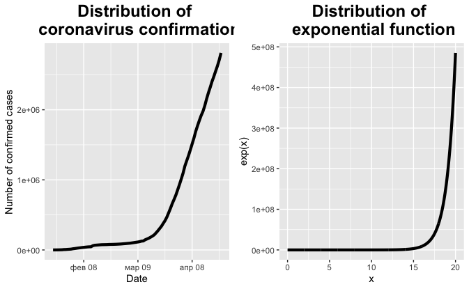

```r
confirmed_by_days <- aggregate(Confirmed ~ ODate, df, sum)
exp_x <- seq(0, 20, length.out = 1000)
exp_data <- data.frame(x=exp_x, y = exp(exp_x))

p1 <- ggplot(confirmed_by_days, aes(x=ODate, y=Confirmed)) +
  geom_line(size=1.5) +
  xlab("Date") +
  ylab("Number of confirmed cases") +
  ggtitle("Distribution of \n coronavirus confirmation") +
  theme(plot.title = element_text(face='bold',
                                  colour='black', size=18, hjust = 0.5)) +
  scale_x_date(date_labels = "%b %d", date_breaks = "30 days")
p2 <- ggplot(data = exp_data, aes(x=x, y=y)) +
  geom_line(size=1.5) +
  xlab("x") +
  ylab("exp(x)") +
  ggtitle("Distribution of \n exponential function") +
  theme(plot.title = element_text(face='bold', colour='black', size=18, hjust = 0.5))

grid.arrange(p1, p2, nrow = 1)
```

But, I think, it’s not a reason for a panic, because we (humanity) can change the constant inside the exponent function and this distribution will turn into *Logistic curve*.

The sad plot is a distribution deaths by days. Spoiler: it depends on a number of confirmed issues, so it’s obvious that the curve will be simillar…

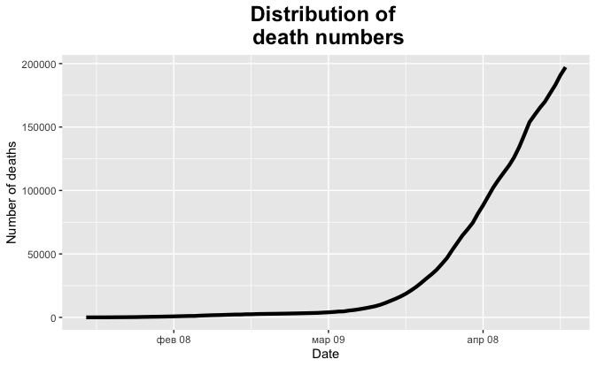

```r
deaths_by_days <- aggregate(Deaths ~ ODate, df, sum)

ggplot(deaths_by_days, aes(x=ODate, y=Deaths)) +
  geom_line(size=1.5) +
  xlab("Date") +
  ylab("Number of deaths") +
  ggtitle("Distribution of \n death numbers") +
  theme(plot.title = element_text(face='bold',
                                  colour='black', size=18, hjust = 0.5)) +
  scale_x_date(date_labels = "%b %d", date_breaks = "30 days")
```

Time for good news: there is distribution of recovering (guess what, it depends on number of confirmed!)

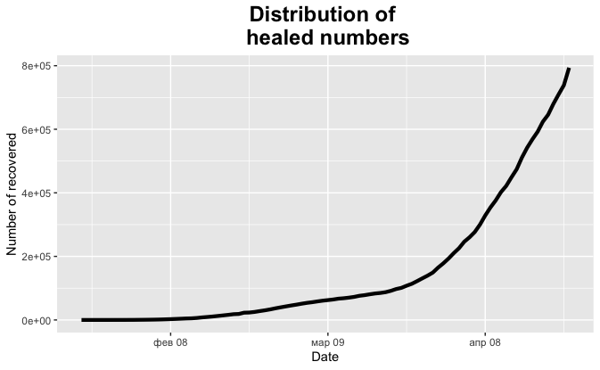

```r
recovered_by_days <- aggregate(Recovered ~ ODate, df, sum)

ggplot(recovered_by_days, aes(x=ODate, y=Recovered)) +
  geom_line(size=1.5) +
  xlab("Date") +
  ylab("Number of recovered") +
  ggtitle("Distribution of \n healed numbers") +
  theme(plot.title = element_text(face='bold',
                                  colour='black', size=18, hjust = 0.5)) +
  scale_x_date(date_labels = "%b %d", date_breaks = "30 days")
```

To estimate the real mortality situation we should rate the $\frac{number of deaths}{number of confirmed}$:

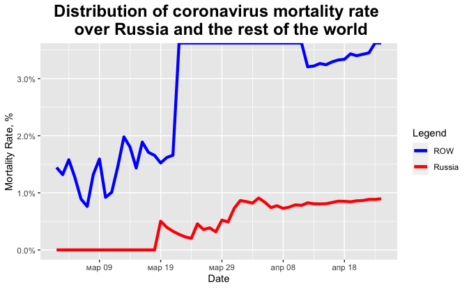

```r
mortality <- data.frame(x=df$ODate, y = df$Deaths/df$Confirmed)
mortality <- mortality[mortality$x>"2020-03-01", ]
mortality <- mortality[complete.cases(mortality), ]

russia = subset(df, df$Country.Region == 'Russia')
r_mortality <- data.frame(x=russia$ODate, y = russia$Deaths/russia$Confirmed)
r_mortality <- r_mortality[r_mortality$x>"2020-03-01", ]
r_mortality <- r_mortality[complete.cases(r_mortality), ]

colors <- c("Russia" = "red", "ROW" = "blue")
ggplot(aggregate(y ~ x, r_mortality, mean),
       aes(x=x, y=y, color='Russia')) +
  geom_line(size=1.5) +
  geom_line(data = aggregate(y ~ x, mortality, mean),
            aes(x = x, y = y, color = 'ROW'), size=1.5) +
  labs(x = 'Date',
    y = 'Mortality Rate, %',
    title = "Distribution of coronavirus mortality rate \n over Russia and the rest of the world",
    color = 'Legend') +
  theme(plot.title = element_text(face='bold',
                                  colour='black', size=18, hjust = 0.5)) +
  scale_x_date(date_labels = "%b %d", date_breaks = "10 days") +
  scale_y_continuous(labels = scales::percent) +
  scale_color_manual(values = colors)
```

Yes, there is a small growth, but the share of deaths is under 1% in Russia (or may be we don’t know something…)

Speaking about Russia, let’s check a summary:

```r
describe(russia[, c(6, 7, 8)], skew=F)
```

|  | vars | n | mean | sd | min | max | range | se |
| --- | --- | --- | --- | --- | --- | --- | --- | --- |
| Confirmed | 1 | 85 | 7053.79 | 15476.08 | 2 | 68622 | 68620 | 1678.62 |
| Deaths | 2 | 85 | 59.33 | 134.88 | 0 | 615 | 615 | 14.63 |
| Recovered | 3 | 85 | 539.98 | 1209.00 | 0 | 5568 | 5568 | 131.13 |

The maximum number of deaths is 615 over all regions.

Loading different data about COVID. Breaking down to confirmed issues:

```r
df = read.csv('~/Documents/se/R/novel-corona-virus-2019-dataset/COVID19_open_line_list.csv',
              na.strings=c("","N/A", "NA"))
head(df)
```

|  | ID | age | sex | city | province | country | wuhan.0._not_wuhan.1. | latitude | longitude | geo_resolution | date_onset_symptoms | date_admission_hospital | date_confirmation | symptoms | lives_in_Wuhan | travel_history_dates | travel_history_location | reported_market_exposure | additional_information | chronic_disease_binary | chronic_disease | source | sequence_available | outcome | date_death_or_discharge | notes_for_discussion | location | admin3 | admin2 | … |
| --- | --- | --- | --- | --- | --- | --- | --- | --- | --- | --- | --- | --- | --- | --- | --- | --- | --- | --- | --- | --- | --- | --- | --- | --- | --- | --- | --- | --- | --- | --- |
| 1 | 1 | 30 | male | Chaohu City, Hefei City | Anhui | China | 1 | 31.64696 | 117.7166 | admin3 | 18.01.2020 | 20.01.2020 | 22.01.2020 | NA | yes | 17.01.2020 | Wuhan | NA | NA | NA | NA | http://ah.people.com.cn/GB/n2/2020/0127/c358266-33746566.html | NA | NA | NA | NA | NA | Chaohu City | Hefei City | … |
| 2 | 2 | 47 | male | Baohe District, Hefei City | Anhui | China | 1 | 31.77863 | 117.3319 | admin3 | 10.01.2020 | 21.01.2020 | 23.01.2020 | NA | no | 10.01.2020 | Luzhou Hunan, via Wuhan | NA | NA | NA | NA | http://ah.people.com.cn/GB/n2/2020/0127/c358266-33746566.html | NA | NA | NA | NA | NA | Baohe District | Hefei City | … |
| 3 | 3 | 49 | male | High-Tech Zone, Hefei City | Anhui | China | 1 | 31.828313 | 117.224844 | point | 15.01.2020 | 20.01.2020 | 23.01.2020 | NA | no | 10.01.2020 | Yinzhou Hunan, via Wuhan | NA | NA | NA | NA | http://ah.people.com.cn/GB/n2/2020/0127/c358266-33746566.html | NA | NA | NA | NA | High-Tech Zone | Shushan District | Hefei City | … |
| 4 | 4 | 47 | female | High-Tech Zone, Hefei City | Anhui | China | 1 | 31.828313 | 117.224844 | point | 17.01.2020 | 20.01.2020 | 23.01.2020 | NA | no | NA | NA | NA | contacted with confirmed case | NA | NA | http://ah.people.com.cn/GB/n2/2020/0127/c358266-33746566.html | NA | NA | NA | NA | High-Tech Zone | Shushan District | Hefei City | … |
| 5 | 5 | 50 | female | Feidong County, Hefei City | Anhui | China | 1 | 32.00123 | 117.5681 | admin3 | 10.01.2020 | 21.01.2020 | 23.01.2020 | NA | no | 07.01.2020 | Wuhan | NA | 06.01.2020 went to Wuhan, 07.01.2020 returned to Hefei | NA | NA | http://ah.people.com.cn/GB/n2/2020/0127/c358266-33746566.html | NA | NA | NA | NA | NA | Feidong County | Hefei City | … |
| 6 | 6 | NA | NA | Lu'an City | Anhui | China | 1 | 31.75941 | 116.3151 | admin2 | NA | NA | 24.01.2020 | pneumonia | NA | NA | NA | NA | NA | NA | NA | http://www.bjnews.com.cn/news/2020/01/24/678777.html | NA | NA | NA | NA | NA | NA | Lu'an City | … |

There are interesting columns for this project: *age*, *sex*

Counting some statistic about genders:

```r
sex <- str_replace(df$sex, 'Female', 'female')
sex <- str_replace(sex, 'Male', 'male')
sex <- na.omit(sex)
sex <- sex [! sex == 4000]
table(sex)
```

```
sex
female   male
   556    707
```

Visualizing the summary:

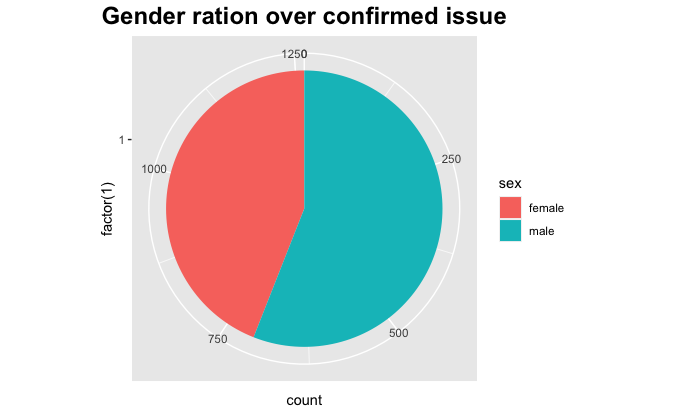

```r
ggplot(data.frame(sex), aes(x=factor(1), fill=sex)) +
  geom_bar(width = 1) +
  coord_polar("y") +
  labs(title = "Gender ration over confirmed issue") +
  theme(plot.title = element_text(face='bold',
                                  colour='black', size=18, hjust = 0.5))
```

Counting some stat about ages distribution:

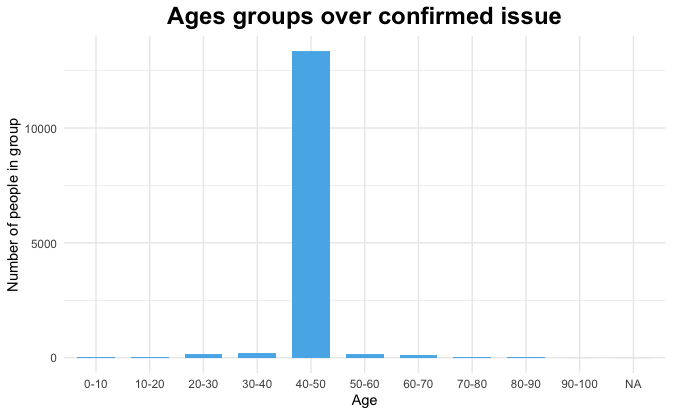

```r
ages <- as.numeric(df$age)
ages[is.na(ages)] <- mean(ages, na.rm=TRUE)
ages <- round(ages)
lbl <- c("0-10", "10-20", "20-30", "30-40", "40-50", "50-60", "60-70",
"70-80", "80-90", "90-100")
ages_cat <- as.factor(cut(ages, breaks = seq(0,100,10), labels = lbl))

ggplot(data.frame(x=ages_cat), aes(x=x))+
  geom_bar(stat="count", width=0.7, fill="#56B4E9", na.rm = T) +
  theme_minimal() +
  labs(x = 'Age',
    y = 'Number of people in group',
    title = "Ages groups over confirmed issue") +
  theme(plot.title = element_text(face='bold',
                                  colour='black', size=18, hjust = 0.5))
```

There is some bag in R, because as we can see there is no NA issues((

```r
table(ages_cat)
```

```
ages_cat
  0-10  10-20  20-30  30-40  40-50  50-60  60-70  70-80  80-90 90-100
    31     31    163    214  13341    163    120     47     11      2
```

There are a lot of researches about COVID-19 in the Internet. The purpose of this Notebook is *getting experience* with data processing and visualizing via R language.

*Ideas*: deep into geographical data from the second dataset, look through sympthoms from the second dataset, aggregate data by location from the first dataset.